# Forecasting Employment in Daytona-Deltona Florida

Kahlil Wehmeyer

3/18/2019

*The purpose of this porject is to forecast the March non seasonally adjusted estimates of average hourly earnings, average weekly hours, average weekly earnings, total employment and total weekly earnings for the Deltona Daytona metropolitan statistical area*

# Introduction

We will be predicting Average Hourly Earnings, Average Weekly Hours and Total Employment.

From there we can calculate average weekly earnings as such:

$$Total Weekly Earnings = Total Employment \times Average Weekly Earnings$$

## Data

The data we will be using is sourced from multiple CSVs downloaded from the FRED.ORG website.

# Data

Here we will import all the data and rename the variables to something more useful. Initaily columns have names starting with `SMU` that are followed by a 15 digit number.

| DATE | Federal_Employees | Healthcare_Employees | Local_Gov_Employees | Retail_Employees | All_Employees | Average_Weekly_Hours | Average_Hourly_Earnings |
| --- | --- | --- | --- | --- | --- | --- | --- |
| 2018-08-01 | 1.4 | 10.0 | 17.6 | 30.7 | 180.4 | 32.8 | 21.83 |
| 2018-09-01 | 1.5 | 10.1 | 18.0 | 30.8 | 180.1 | 33.1 | 21.62 |
| 2018-10-01 | 1.5 | 10.1 | 18.1 | 31.2 | 181.3 | 32.2 | 21.85 |
| 2018-11-01 | 1.5 | 10.1 | 18.1 | 31.8 | 182.4 | 33.2 | 21.68 |
| 2018-12-01 | 1.5 | 10.1 | 18.1 | 31.9 | 182.8 | 32.9 | 22.28 |
| 2019-01-01 | 1.5 | 10.1 | 18.0 | 31.5 | 182.5 | 32.4 | 21.39 |

Now we can apply the previously mentioned calculations to get Average Weekly Earnings and Total Weekly Earnings.

| DATE | Federal_Employees | Healthcare_Employees | Local_Gov_Employees | Retail_Employees | All_Employees | Average_Weekly_Hours | Average_Hourly_Earnings | Average_Weekly_Earnings | Total_Weekly_Earnings |
| --- | --- | --- | --- | --- | --- | --- | --- | --- | --- |
| 2018-08-01 | 1.4 | 10.0 | 17.6 | 30.7 | 180.4 | 32.8 | 21.83 | 716.024 | 129170.7 |
| 2018-09-01 | 1.5 | 10.1 | 18.0 | 30.8 | 180.1 | 33.1 | 21.62 | 715.622 | 128883.5 |
| 2018-10-01 | 1.5 | 10.1 | 18.1 | 31.2 | 181.3 | 32.2 | 21.85 | 703.570 | 127557.2 |
| 2018-11-01 | 1.5 | 10.1 | 18.1 | 31.8 | 182.4 | 33.2 | 21.68 | 719.776 | 131287.1 |
| 2018-12-01 | 1.5 | 10.1 | 18.1 | 31.9 | 182.8 | 32.9 | 22.28 | 733.012 | 133994.6 |
| 2019-01-01 | 1.5 | 10.1 | 18.0 | 31.5 | 182.5 | 32.4 | 21.39 | 693.036 | 126479.1 |

## Summary Statistics

```
##       DATE            Federal_Employees Healthcare_Employees
##  Min.   :1990-01-01   Min.   :1.100     Min.   : 4.900
##  1st Qu.:1997-04-01   1st Qu.:1.300     1st Qu.: 6.300
##  Median :2004-07-01   Median :1.400     Median : 7.600
##  Mean   :2004-07-01   Mean   :1.407     Mean   : 7.392
##  3rd Qu.:2011-10-01   3rd Qu.:1.500     3rd Qu.: 8.400
##  Max.   :2019-01-01   Max.   :2.700     Max.   :10.100
##
##  Local_Gov_Employees Retail_Employees All_Employees   Average_Weekly_Hours
##  Min.   :15.40       Min.   :18.90    Min.   :104.2   Min.   :30.60
##  1st Qu.:18.10       1st Qu.:23.90    1st Qu.:126.6   1st Qu.:32.90
##  Median :18.90       Median :26.30    Median :147.0   Median :33.80
##  Mean   :19.16       Mean   :25.95    Mean   :143.4   Mean   :33.83
##  3rd Qu.:20.10       3rd Qu.:28.30    3rd Qu.:159.7   3rd Qu.:34.70
##  Max.   :23.30       Max.   :31.90    Max.   :182.8   Max.   :36.50
##                                                       NA's   :204
##  Average_Hourly_Earnings Average_Weekly_Earnings Total_Weekly_Earnings
##  Min.   :16.46           Min.   :530.9           Min.   : 79215
##  1st Qu.:18.07           1st Qu.:600.5           1st Qu.: 92866
##  Median :18.98           Median :646.0           Median :105132
##  Mean   :19.76           Mean   :669.8           Mean   :107341
##  3rd Qu.:21.57           3rd Qu.:723.1           3rd Qu.:124108
##  Max.   :26.11           Max.   :930.1           Max.   :147511
##  NA's   :204             NA's   :204             NA's   :204
```

## Time Series Lines

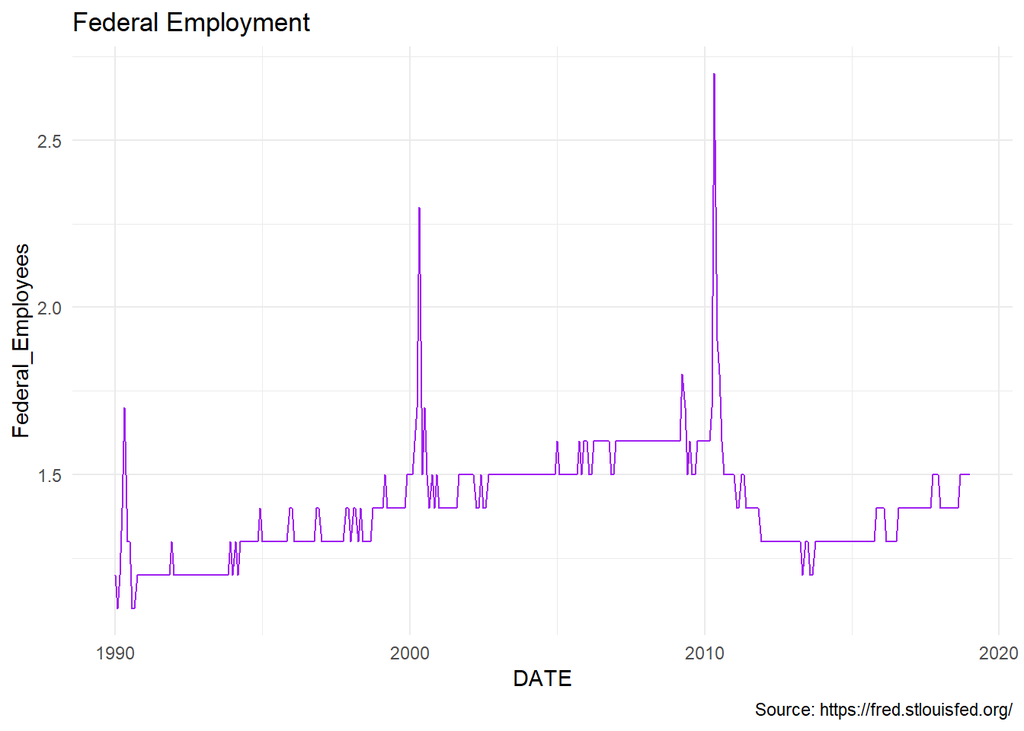

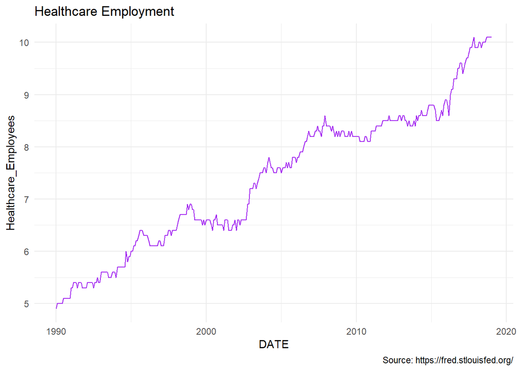

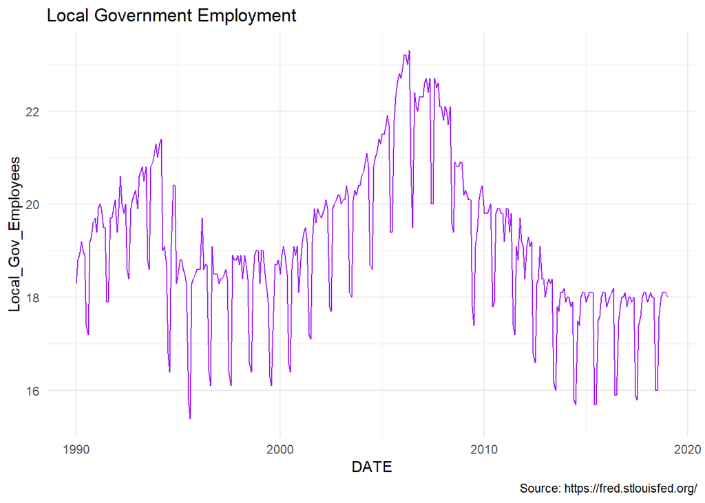

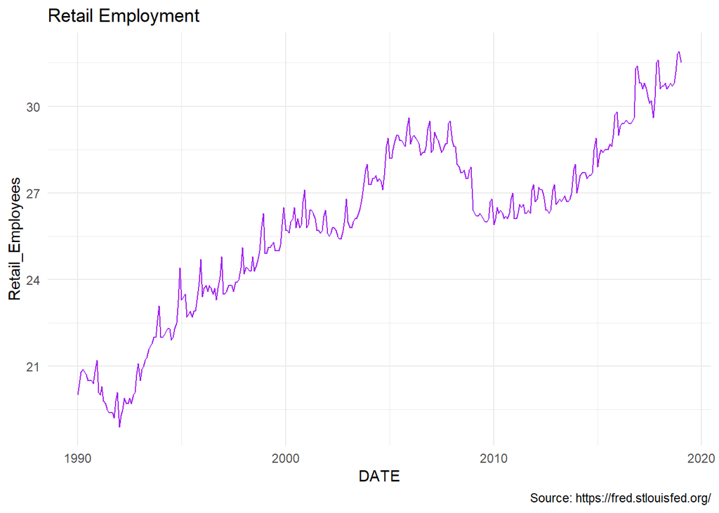

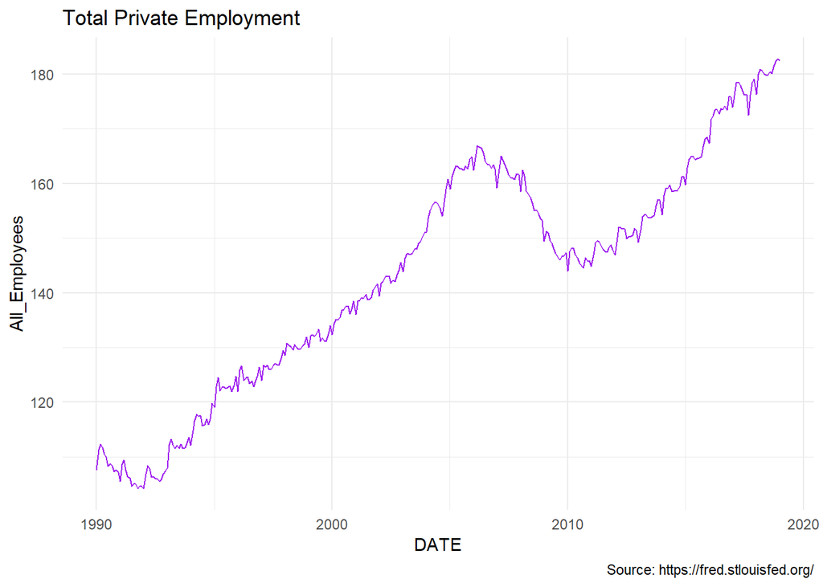

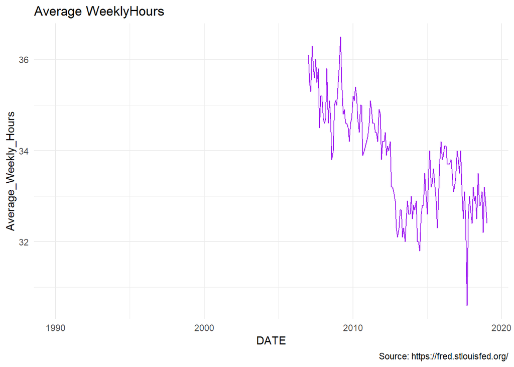

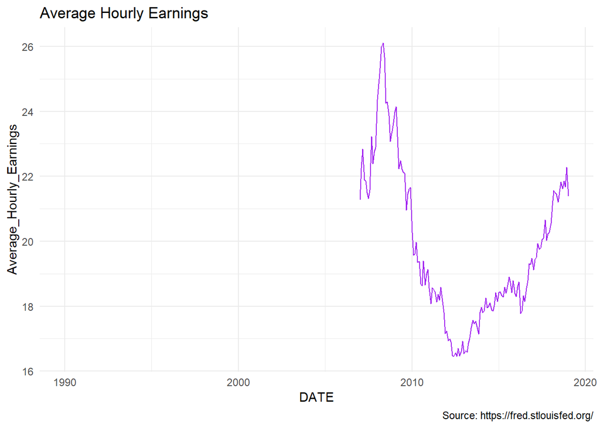

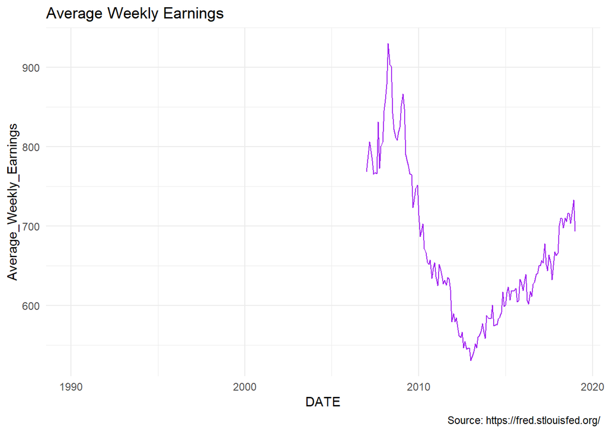

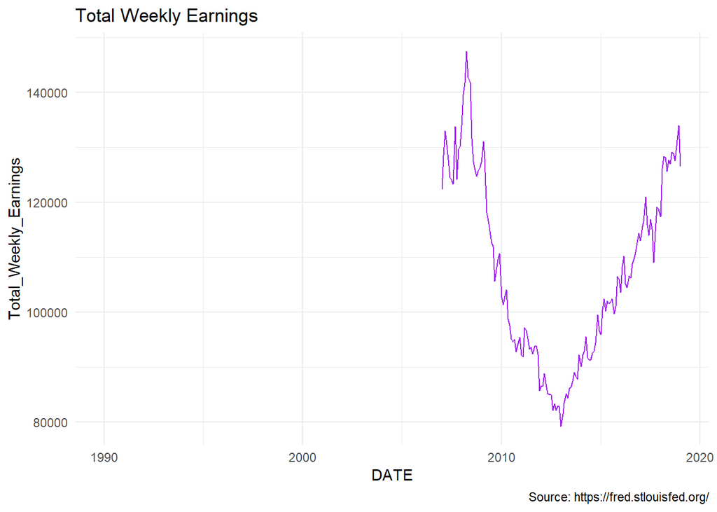

## PACS

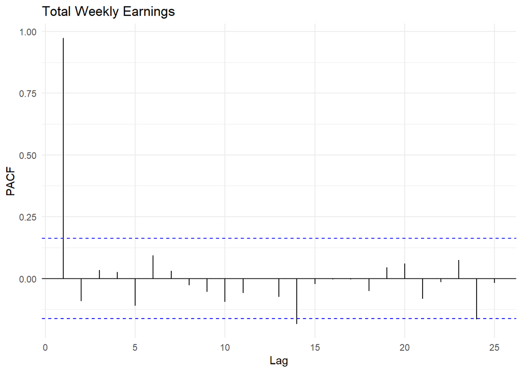

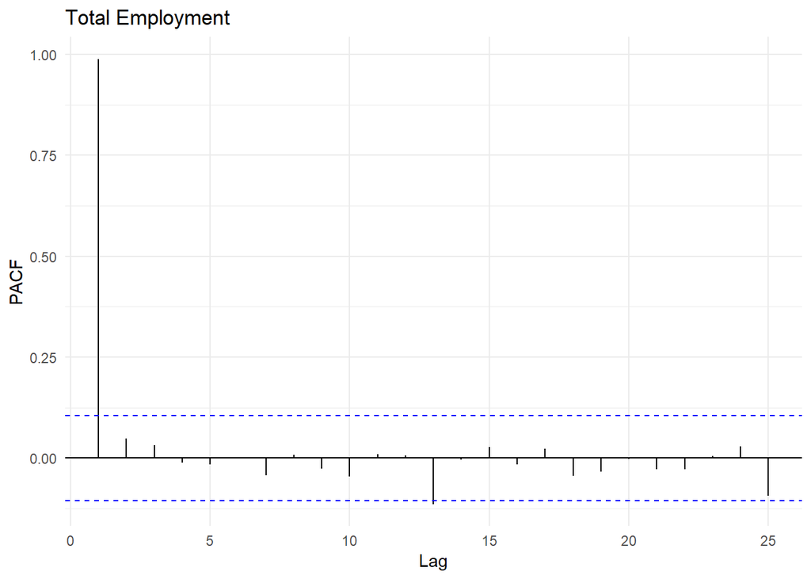

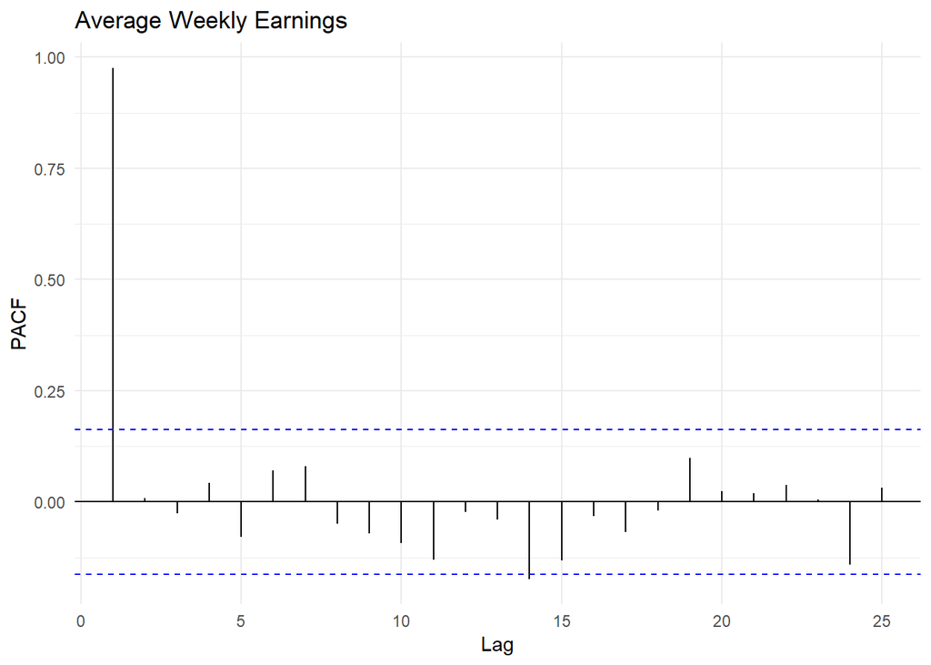

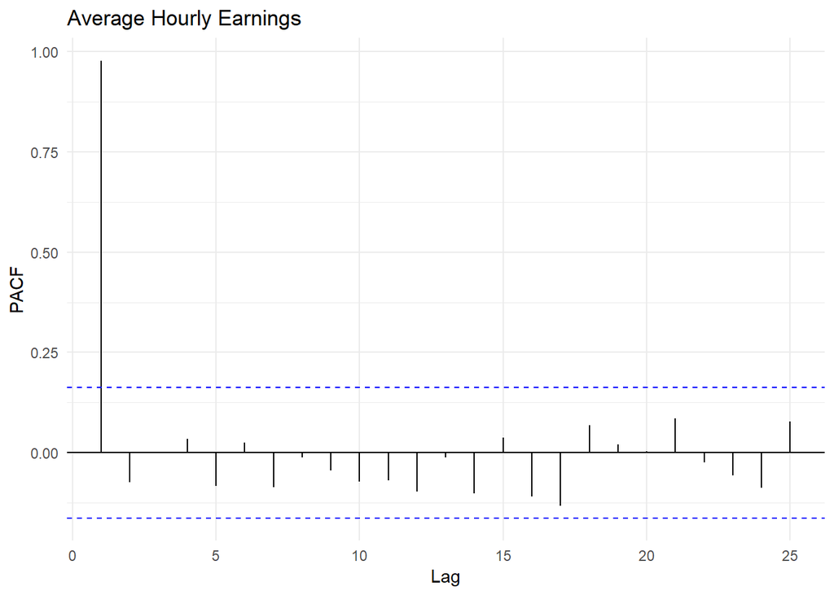

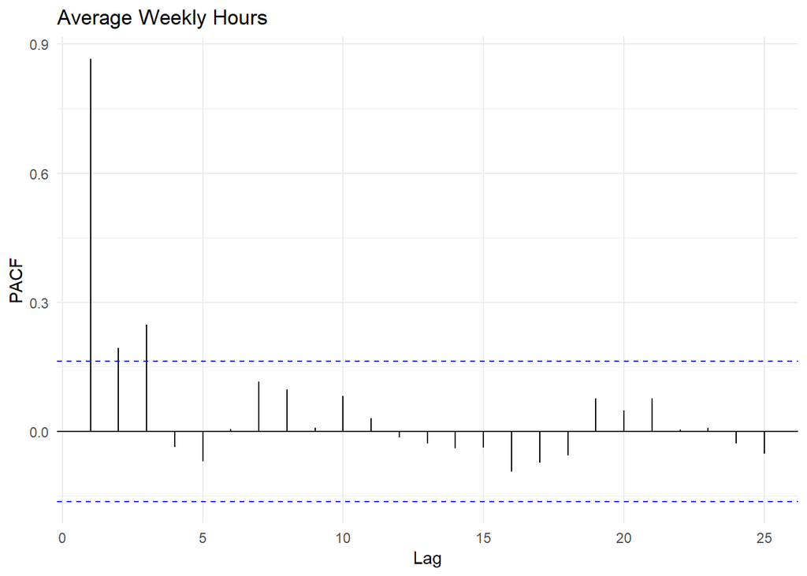

# Preliminary Models

## Simple Models

### Average Method

Forecasts of all future values are equal to the mean of the historical data. $\hat{y}_{T+h|T} = \bar{y} = (y_{1}+\dots+y_{T})/T$

```
##          Point Forecast    Lo 80    Hi 80    Lo 95    Hi 95
## Feb 2019       160.1759 145.3303 175.0214 137.3842 182.9675
## Mar 2019       160.1759 145.3303 175.0214 137.3842 182.9675
## Apr 2019       160.1759 145.3303 175.0214 137.3842 182.9675
## May 2019       160.1759 145.3303 175.0214 137.3842 182.9675
```

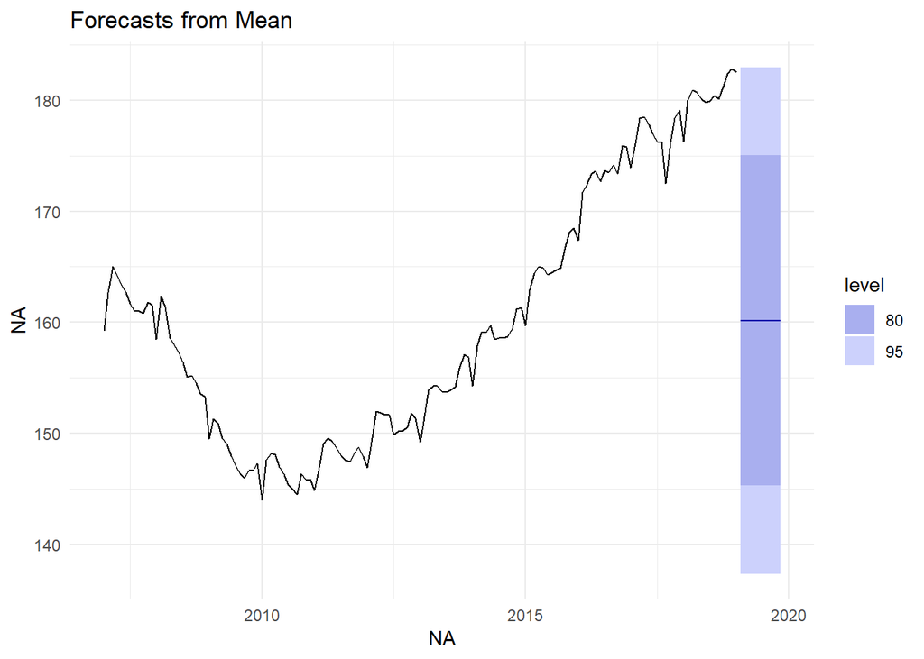

Doesn’t look like the ideal method.

### Naive Method

All forecasts are set to the value of the last observation. $\hat{y}_{T+h|T} = y_{T}$

```
##          Point Forecast    Lo 80    Hi 80    Lo 95    Hi 95
## Feb 2019          182.5 180.5861 184.4139 179.5730 185.4270
## Mar 2019          182.5 179.7934 185.2066 178.3606 186.6394
## Apr 2019          182.5 179.1851 185.8149 177.4303 187.5697
## May 2019          182.5 178.6723 186.3277 176.6460 188.3540
```

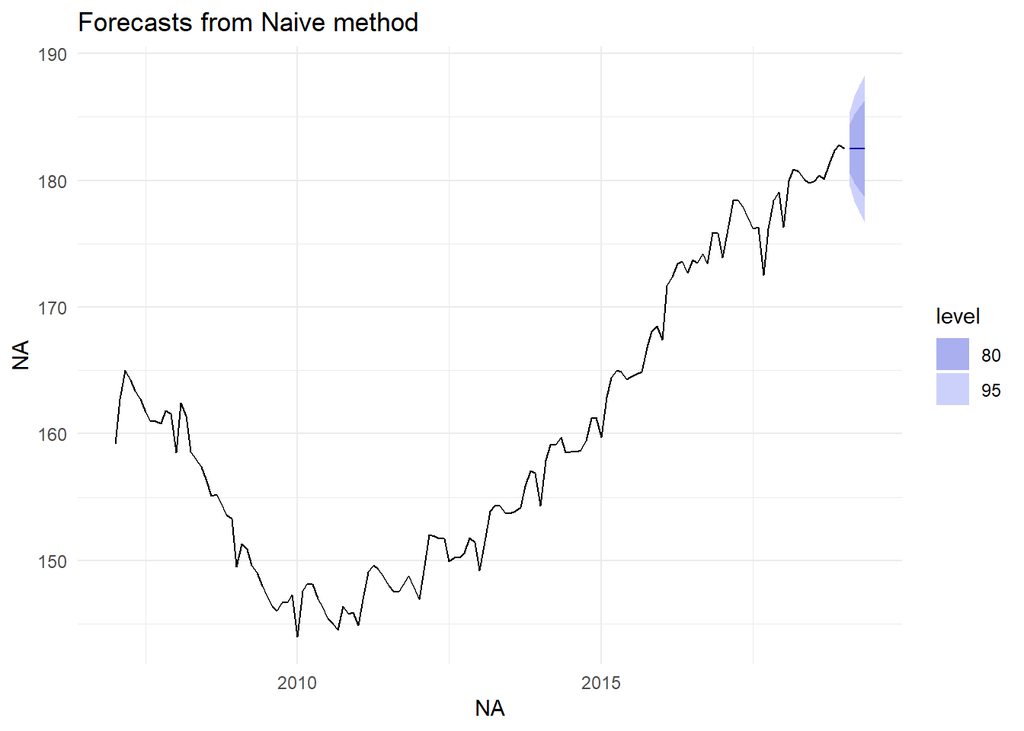

This looks more reasonable but the forecast doesn’t change no matter how many period we go out.

### Seasonal Naive Method

A similar method is useful for highly seasonal data. Here we set each foecast to be the equal to the last observed value from the same season of the year. $\hat{y}_{T+h|T} = y_{T+h-m(k+1)},$

```
##          Point Forecast    Lo 80    Hi 80    Lo 95    Hi 95
## Feb 2019          180.0 173.2621 186.7379 169.6953 190.3047
## Mar 2019          180.9 174.1621 187.6379 170.5953 191.2047
## Apr 2019          180.7 173.9621 187.4379 170.3953 191.0047
## May 2019          180.1 173.3621 186.8379 169.7953 190.4047
```

[figure not shown]

### Drift Method

This is a variation on the naive method which allows the forecast to increase or decrease over time. The amount of change, drift, is set to be the average change seen in the historical data. $\hat{y}_{T+h|T} = y_{T} + \frac{h}{T-1}\sum_{t=2}^T (y_{t}-y_{t-1}) = y_{T} + h \left( \frac{y_{T} -y_{1}}{T-1}\right)$

```
##          Point Forecast    Lo 80    Hi 80    Lo 95    Hi 95
## Feb 2019       182.6618 180.7460 184.5777 179.7318 185.5918
## Mar 2019       182.8236 180.0956 185.5516 178.6514 186.9958
## Apr 2019       182.9854 179.6216 186.3492 177.8409 188.1299
## May 2019       183.1472 179.2371 187.0574 177.1671 189.1273
```

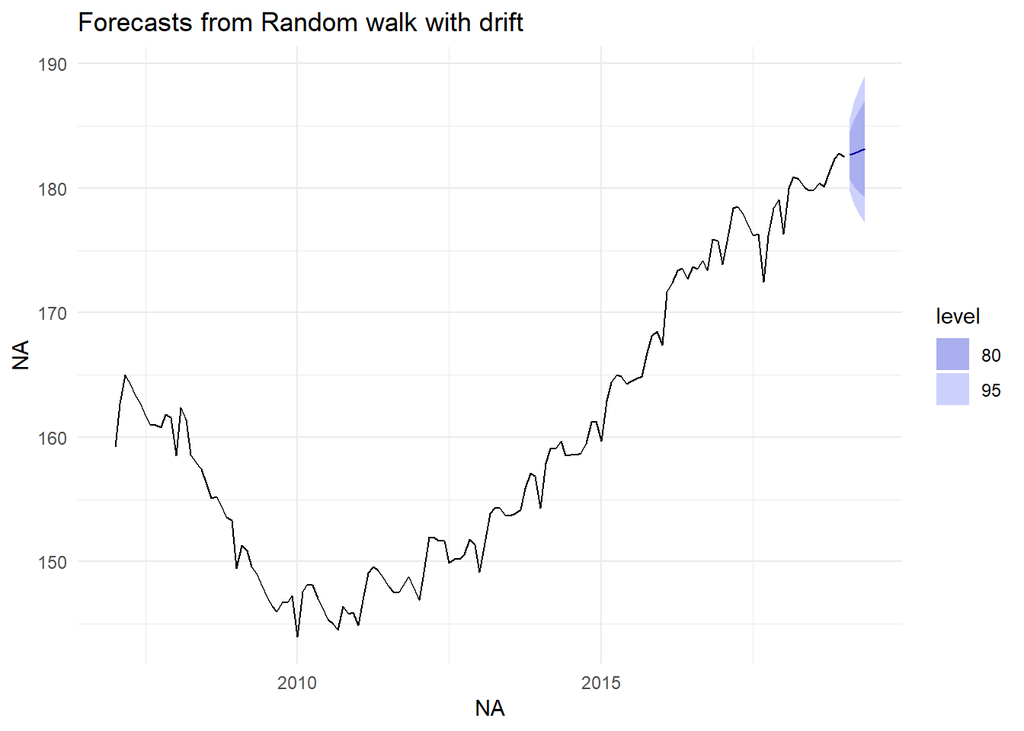

Another marginal improvement.

# Linear Models

## Pure Auto Regressive

### ARIMA AWH Model A1

```
## Series: na.omit(TSA[, "Average_Weekly_Hours"])
## ARIMA(0,2,12)
##
## Coefficients:
##           ma1     ma2     ma3      ma4      ma5     ma6     ma7      ma8
##       -1.3573  0.1475  0.2941  -0.0165  -0.2464  0.0771  0.1885  -0.0886
## s.e.   0.0878  0.1401  0.1392   0.1529   0.1600  0.1627  0.1584   0.1414
##          ma9     ma10    ma11     ma12
##       0.0181  -0.0646  0.1938  -0.1457
## s.e.  0.1685   0.1771  0.1698   0.0912
##
## sigma^2 estimated as 0.2549:  log likelihood=-102.46
## AIC=230.92   AICc=233.74   BIC=269.44
##
## Training set error measures:
##                      ME      RMSE       MAE        MPE     MAPE      MASE
## Training set 0.03365823 0.4799111 0.3732031 0.08482544 1.108365 0.5308664
##                      ACF1
## Training set -0.008219666
```

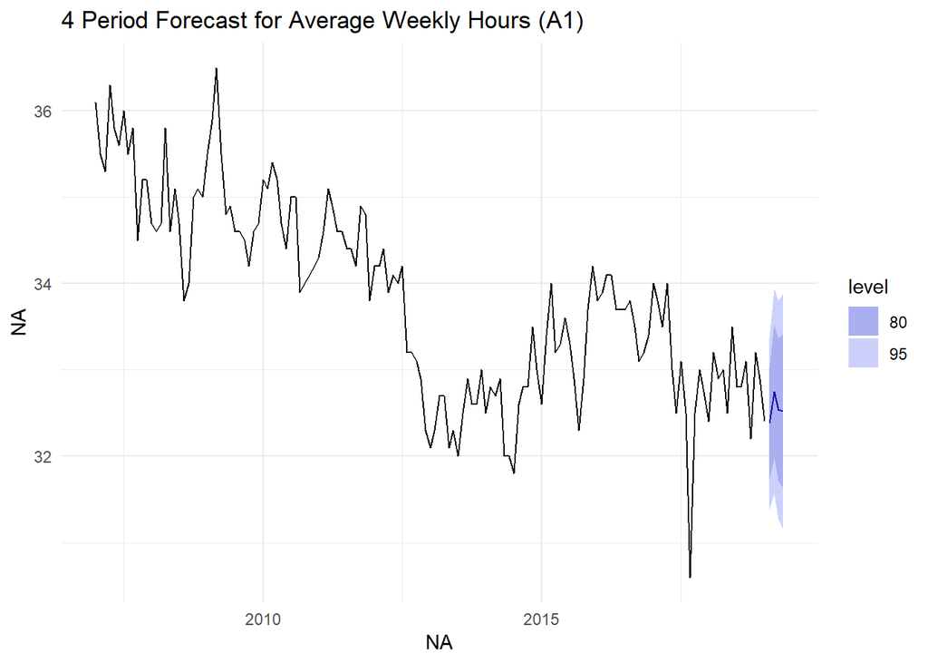

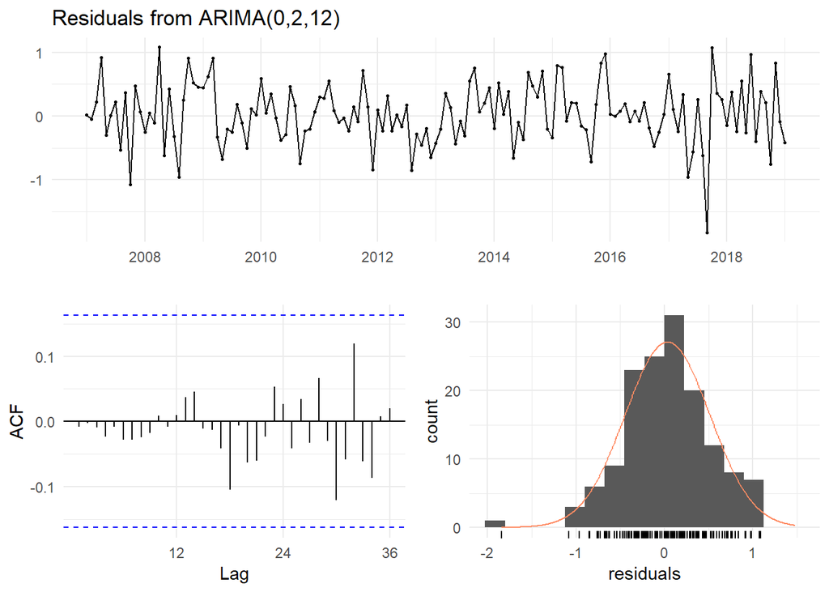

```
##
##  Ljung-Box test
##
## data:  Residuals from ARIMA(0,2,12)
## Q* = 5.3117, df = 12, p-value = 0.9468
##
## Model df: 12.   Total lags used: 24
```

### ARIMA AWH Model A2

```
## Series: na.omit(TSA[, "Average_Weekly_Hours"])
## ARIMA(0,1,2)
##
## Coefficients:
##           ma1      ma2
##       -0.3341  -0.2182
## s.e.   0.0830   0.0890
##
## sigma^2 estimated as 0.2548:  log likelihood=-105.02
## AIC=216.03   AICc=216.21   BIC=224.94
##
## Training set error measures:
##                       ME      RMSE       MAE        MPE     MAPE      MASE
## Training set -0.05080397 0.4995079 0.3884852 -0.1653134 1.153632 0.5526046
##                     ACF1
## Training set -0.01608952
```

[figure not shown]

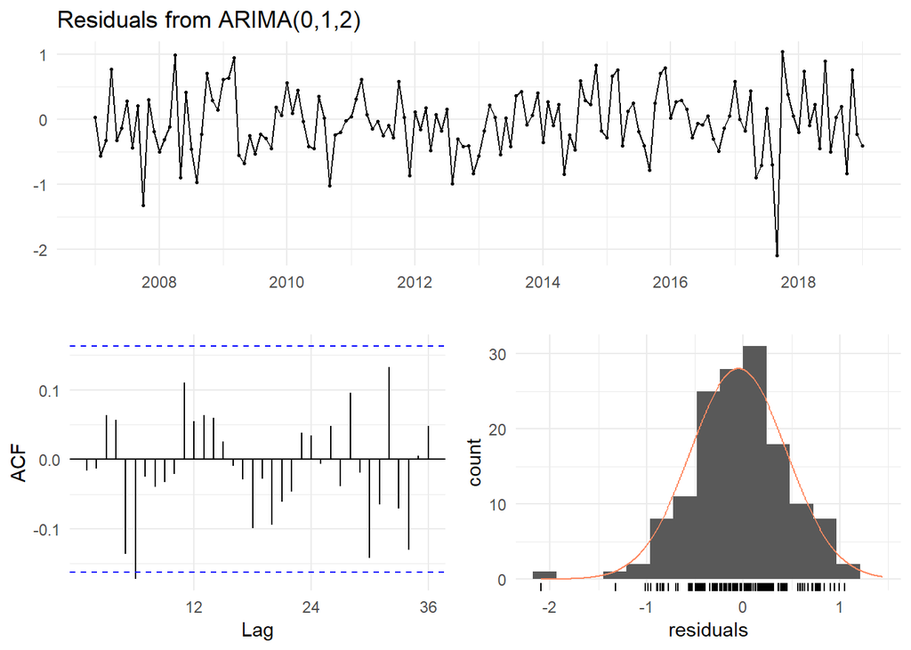

```
##
##  Ljung-Box test
##
## data:  Residuals from ARIMA(0,1,2)
## Q* = 17.851, df = 22, p-value = 0.7148
##
## Model df: 2.   Total lags used: 24
```

```
## Series: na.omit(TSA[, "Average_Hourly_Earnings"])
## ARIMA(0,2,12)
##
## Coefficients:
##           ma1      ma2     ma3     ma4      ma5     ma6      ma7     ma8
##       -1.0007  -0.0061  0.0282  0.0668  -0.1819  0.1689  -0.1472  0.0411
## s.e.   0.0975   0.1271  0.1359  0.1514   0.1514  0.1475   0.1481  0.1471
##          ma9     ma10    ma11     ma12
##       0.1574  -0.0067  0.0306  -0.1505
## s.e.  0.1732   0.1978  0.1578   0.1224
##
## sigma^2 estimated as 0.2206:  log likelihood=-91.15
## AIC=208.31   AICc=211.13   BIC=246.82
##
## Training set error measures:
##                       ME      RMSE       MAE         MPE     MAPE
## Training set -0.01675694 0.4464473 0.3249535 -0.06468021 1.609913
##                   MASE        ACF1
## Training set 0.2293018 0.008154808
```

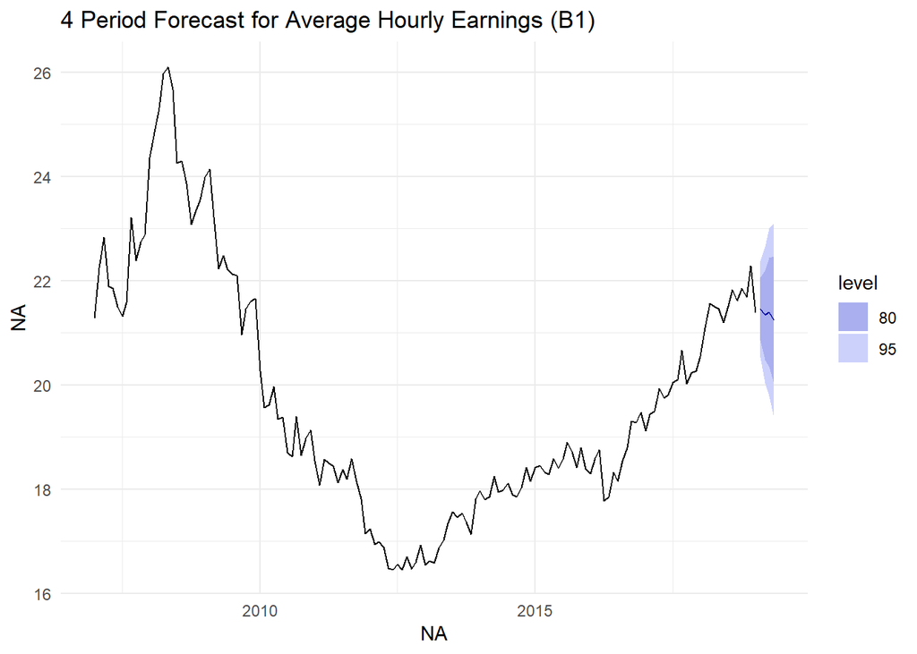

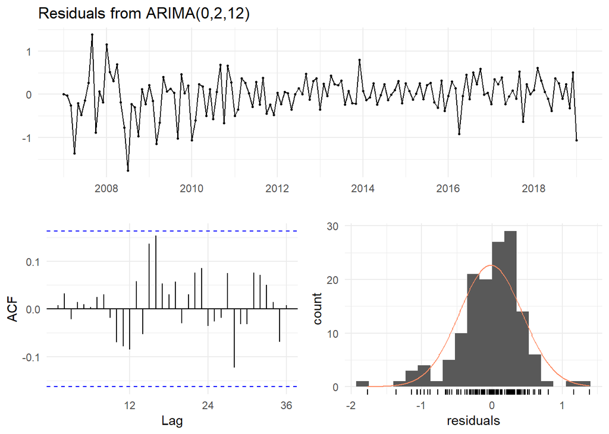

```
##
##  Ljung-Box test
##
## data:  Residuals from ARIMA(0,2,12)
## Q* = 15.43, df = 12, p-value = 0.2187
##
## Model df: 12.   Total lags used: 24
```

### AR AHE Model B2

```
## Series: na.omit(TSA[, "Average_Hourly_Earnings"])
## ARIMA(0,1,0)
##
## sigma^2 estimated as 0.2125:  log likelihood=-92.83
## AIC=187.65   AICc=187.68   BIC=190.62
##
## Training set error measures:
##                        ME      RMSE       MAE         MPE     MAPE
## Training set 0.0009053792 0.4594311 0.3398019 -0.01992184 1.682302
##                   MASE        ACF1
## Training set 0.2397796 -0.02339292
```

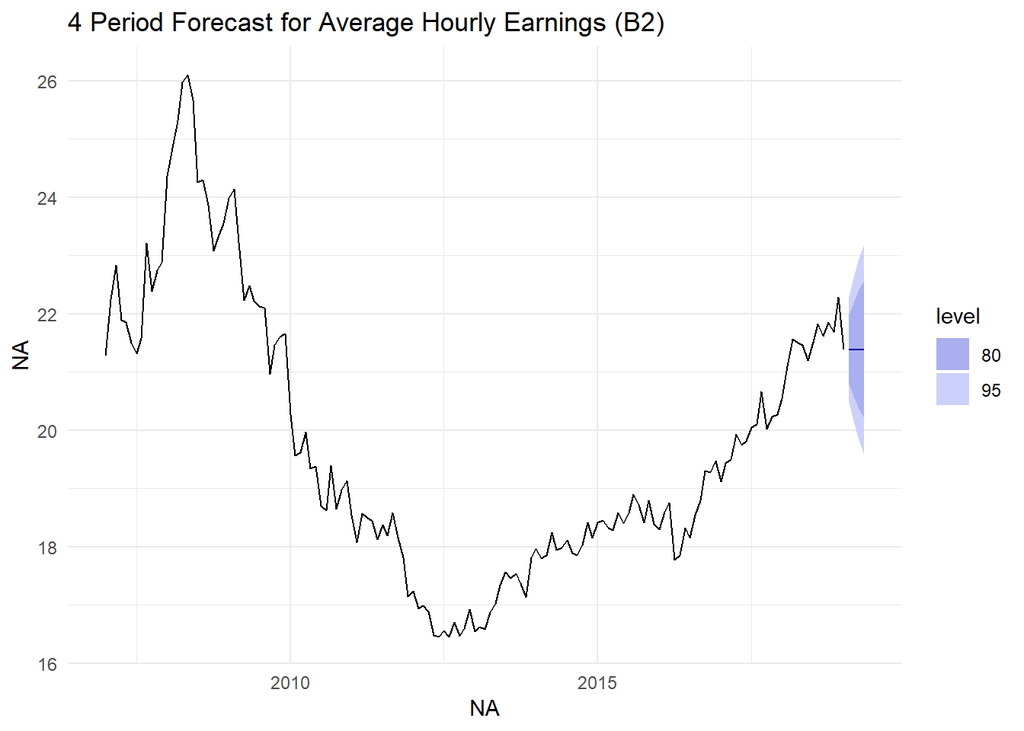

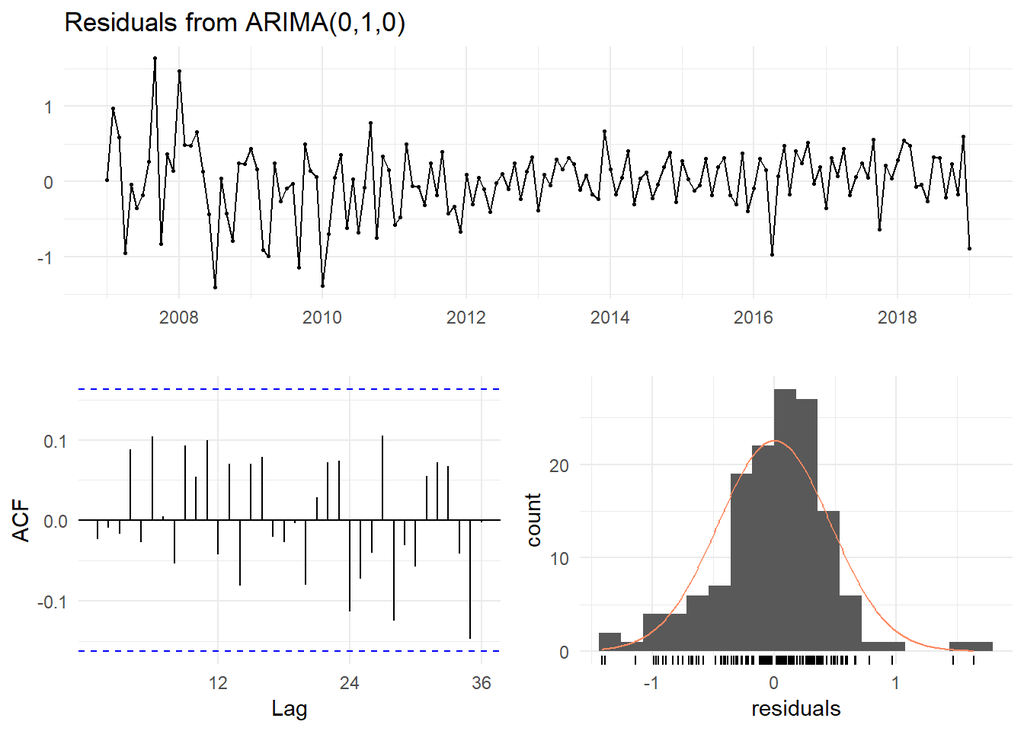

```
##
##  Ljung-Box test
##
## data:  Residuals from ARIMA(0,1,0)
## Q* = 16.515, df = 24, p-value = 0.8686
##
## Model df: 0.   Total lags used: 24
```

### AR TE Model C1

[output not shown]

[figure not shown]

[figure not shown]

[output not shown]

# Checkpoint 2 Disclaimer

Hello Dr. Dewey,

If it isn’t already apparent I’ve elected to try my best to complete this project in R. I’ve been reading a couple supplementary textbooks and hope to meet your standards. I know that there isn’t a plethora of suitable models in this document and hopefully interpretting the results isn’t too cryptic for you. I know Owen is also going to be attempting to do this in R and as I’ve mentioned previously we will be helping each other.

## Biggest Challenges

- Lags: Using lags in R is a little different from STATA because you can either use a lagging function or create a new variable. Encorporating this into a model is something I haven’t quite decyphered
- Cross Validation: This isn’t a huge challenge since these is a lot of functions in R that performs cross validation in R. But I have yet to test and implement them
- Rolling Window: I have a couple packages that I’m reading the documentation for. One of them has a `roll_lm` package for doing linear modeling. Yet to test this and hopefully it achieves something similar to your STATA code.

## Things to be completed

- More rigorous model selection and evaluation
  - Rolling Window
  - GSREG
  - Cross Validation
- Proper forecasting
  - Once model is selected and validated
  - Make forecast and plots